# Diamond -PCA

DIAMOND data set:-

A data frame with 53940 rows and 10 variables:

price-price in US dollars ($326–$18,823) carat-weight of the diamond (0.2–5.01) cut-quality of the cut (Fair, Good, Very Good, Premium, Ideal) color-diamond colour, from J (worst) to D (best) clarity-a measurement of how clear the diamond is (I1 (worst), SI2, SI1, VS2, VS1, VVS2, VVS1, IF (best)) x-length in mm (0–10.74) y-width in mm (0–58.9) z-depth in mm (0–31.8) depth-total depth percentage = z / mean(x, y) = 2 * z / (x + y) (43–79) table-width of top of diamond relative to widest point (43–95)

```r
setwd("F:\\R Programming\\Working Directory\\PCA practice")
R.diamond<- read.csv("diamonds.csv")
head(R.diamond)
```

```
##   X carat       cut color clarity depth table price    x    y    z
## 1 1  0.23     Ideal     E     SI2  61.5    55   326 3.95 3.98 2.43
## 2 2  0.21   Premium     E     SI1  59.8    61   326 3.89 3.84 2.31
## 3 3  0.23      Good     E     VS1  56.9    65   327 4.05 4.07 2.31
## 4 4  0.29   Premium     I     VS2  62.4    58   334 4.20 4.23 2.63
## 5 5  0.31      Good     J     SI2  63.3    58   335 4.34 4.35 2.75
## 6 6  0.24 Very Good     J    VVS2  62.8    57   336 3.94 3.96 2.48
```

```r
str(R.diamond)
```

```
## 'data.frame':    53940 obs. of  11 variables:
##  $ X      : int  1 2 3 4 5 6 7 8 9 10 ...
##  $ carat  : num  0.23 0.21 0.23 0.29 0.31 0.24 0.24 0.26 0.22 0.23 ...
##  $ cut    : Factor w/ 5 levels "Fair","Good",..: 3 4 2 4 2 5 5 5 1 5 ...
##  $ color  : Factor w/ 7 levels "D","E","F","G",..: 2 2 2 6 7 7 6 5 2 5 ...
##  $ clarity: Factor w/ 8 levels "I1","IF","SI1",..: 4 3 5 6 4 8 7 3 6 5 ...
##  $ depth  : num  61.5 59.8 56.9 62.4 63.3 62.8 62.3 61.9 65.1 59.4 ...
##  $ table  : num  55 61 65 58 58 57 57 55 61 61 ...
##  $ price  : int  326 326 327 334 335 336 336 337 337 338 ...
##  $ x      : num  3.95 3.89 4.05 4.2 4.34 3.94 3.95 4.07 3.87 4 ...
##  $ y      : num  3.98 3.84 4.07 4.23 4.35 3.96 3.98 4.11 3.78 4.05 ...
##  $ z      : num  2.43 2.31 2.31 2.63 2.75 2.48 2.47 2.53 2.49 2.39 ...
```

```r
summary(R.diamond)
```

```
##        X             carat               cut        color        clarity
##  Min.   :    1   Min.   :0.2000   Fair     : 1610   D: 6775   SI1    :13065
##  1st Qu.:13486   1st Qu.:0.4000   Good     : 4906   E: 9797   VS2    :12258
##  Median :26971   Median :0.7000   Ideal    :21551   F: 9542   SI2    : 9194
##  Mean   :26971   Mean   :0.7979   Premium  :13791   G:11292   VS1    : 8171
##  3rd Qu.:40455   3rd Qu.:1.0400   Very Good:12082   H: 8304   VVS2   : 5066
##  Max.   :53940   Max.   :5.0100                     I: 5422   VVS1   : 3655
##                                                     J: 2808   (Other): 2531
##      depth           table           price             x
##  Min.   :43.00   Min.   :43.00   Min.   :  326   Min.   : 0.000
##  1st Qu.:61.00   1st Qu.:56.00   1st Qu.:  950   1st Qu.: 4.710
##  Median :61.80   Median :57.00   Median : 2401   Median : 5.700
##  Mean   :61.75   Mean   :57.46   Mean   : 3933   Mean   : 5.731
##  3rd Qu.:62.50   3rd Qu.:59.00   3rd Qu.: 5324   3rd Qu.: 6.540
##  Max.   :79.00   Max.   :95.00   Max.   :18823   Max.   :10.740
##
##        y                z
##  Min.   : 0.000   Min.   : 0.000
##  1st Qu.: 4.720   1st Qu.: 2.910
##  Median : 5.710   Median : 3.530
##  Mean   : 5.735   Mean   : 3.539
##  3rd Qu.: 6.540   3rd Qu.: 4.040
##  Max.   :58.900   Max.   :31.800
##
```

```r
dim(R.diamond)
```

```
## [1] 53940    11
```

```r
require(caTools)
set.seed(3) #setting randomaization to 3 will pick every 3 dataset from the lot.
sample = sample.split(R.diamond, SplitRatio=0.75) # Spiltting the dataset to 75%.
train.dia = subset(R.diamond, sample==TRUE)#sample randomzing so making as true. True is alloted to Train
test.dia = subset(R.diamond, sample==FALSE)#False is alloted to test

head (sample)# head will give first 7 rows
```

```
## [1]  TRUE FALSE  TRUE  TRUE  TRUE FALSE
```

```r
head (train.dia)
```

```
##   X carat       cut color clarity depth table price    x    y    z
## 1 1  0.23     Ideal     E     SI2  61.5    55   326 3.95 3.98 2.43
## 3 3  0.23      Good     E     VS1  56.9    65   327 4.05 4.07 2.31
## 4 4  0.29   Premium     I     VS2  62.4    58   334 4.20 4.23 2.63
## 5 5  0.31      Good     J     SI2  63.3    58   335 4.34 4.35 2.75
## 7 7  0.24 Very Good     I    VVS1  62.3    57   336 3.95 3.98 2.47
## 8 8  0.26 Very Good     H     SI1  61.9    55   337 4.07 4.11 2.53
```

```r
head (test.dia)
```

```
##     X carat       cut color clarity depth table price    x    y    z
## 2   2  0.21   Premium     E     SI1  59.8    61   326 3.89 3.84 2.31
## 6   6  0.24 Very Good     J    VVS2  62.8    57   336 3.94 3.96 2.48
## 10 10  0.23 Very Good     H     VS1  59.4    61   338 4.00 4.05 2.39
## 13 13  0.22   Premium     F     SI1  60.4    61   342 3.88 3.84 2.33
## 17 17  0.30     Ideal     I     SI2  62.0    54   348 4.31 4.34 2.68
## 21 21  0.30      Good     I     SI2  63.3    56   351 4.26 4.30 2.71
```

```r
nrow(train.dia) #No. of rows
```

```
## [1] 39229
```

```r
nrow(test.dia)
```

```
## [1] 14711
```

#########rajkr82######### prcomp returns a list with class “prcomp” containing the following components:

sdev  
the standard deviations of the principal components (i.e., the square roots of the eigenvalues of the covariance/correlation matrix, though the calculation is actually done with the singular values of the data matrix).

rotation  
the matrix of variable loadings (i.e., a matrix whose columns contain the eigenvectors). The function princomp returns this in the element loadings.

x  
if retx is true the value of the rotated data (the centred (and scaled if requested) data multiplied by the rotation matrix) is returned. Hence, cov(x) is the diagonal matrix diag(sdev^2). For the formula method, napredict() is applied to handle the treatment of values omitted by the na.action.

center, scale  
the centering and scaling used, or FALSE.

```r
##########PCA analysis is done here##########

PCA.diamond = prcomp(train.dia[ ,c(-1,-3,-4,-5)], center = TRUE,scale. = TRUE)

print("Print PCA.diamond")
```

```
## [1] "Print PCA.diamond"
```

```r
PCA.diamond
```

```
## Standard deviations (1, .., p=7):
## [1] 2.1779432 1.1310113 0.8340341 0.4210365 0.2301464 0.1937737 0.1182236
##
## Rotation (n x k) = (7 x 7):
##                 PC1          PC2         PC3         PC4         PC5
## carat  0.4531192039 -0.036035014  0.00605248 -0.07634752  0.09832724
## depth -0.0008782009 -0.732280287 -0.67100049 -0.04618037 -0.08984044
## table  0.1023365703  0.673064823 -0.72949350 -0.05910084 -0.01096551
## price  0.4259775424 -0.036542139  0.10617388 -0.84458196 -0.05415691
## x      0.4538382615  0.003202126  0.03986473  0.22436761  0.10359680
## y      0.4457587144  0.002188837  0.05658404  0.34660599 -0.76698372
## z      0.4450646881 -0.090002394 -0.03869227  0.32365150  0.61661245
##               PC6          PC7
## carat -0.71314867  0.518911955
## depth -0.01679441 -0.055110479
## table  0.02688370 -0.003783762
## price  0.28098930 -0.103577318
## x     -0.30308146 -0.799687373
## y      0.25500964  0.157044473
## z      0.50455021  0.229755912
```

```r
print("Print Summary PCA.diamond")
```

```
## [1] "Print Summary PCA.diamond"
```

```r
summary(PCA.diamond)# Here have a look at the cumulative percentage
```

```
## Importance of components:
##                           PC1    PC2     PC3     PC4     PC5     PC6    PC7
## Standard deviation     2.1779 1.1310 0.83403 0.42104 0.23015 0.19377 0.1182
## Proportion of Variance 0.6776 0.1827 0.09937 0.02532 0.00757 0.00536 0.0020
## Cumulative Proportion  0.6776 0.8604 0.95975 0.98507 0.99264 0.99800 1.0000
```

```r
print("Print Structure PCA.diamond")
```

```
## [1] "Print Structure PCA.diamond"
```

```r
str(PCA.diamond)
```

```
## List of 5
##  $ sdev    : num [1:7] 2.178 1.131 0.834 0.421 0.23 ...
##  $ rotation: num [1:7, 1:7] 0.453119 -0.000878 0.102337 0.425978 0.453838 ...
##   ..- attr(*, "dimnames")=List of 2
##   .. ..$ : chr [1:7] "carat" "depth" "table" "price" ...
##   .. ..$ : chr [1:7] "PC1" "PC2" "PC3" "PC4" ...
##  $ center  : Named num [1:7] 0.798 61.754 57.461 3933.103 5.731 ...
##   ..- attr(*, "names")= chr [1:7] "carat" "depth" "table" "price" ...
##  $ scale   : Named num [1:7] 0.474 1.434 2.24 3989.438 1.122 ...
##   ..- attr(*, "names")= chr [1:7] "carat" "depth" "table" "price" ...
##  $ x       : num [1:39229, 1:7] -3.13 -2.67 -2.62 -2.42 -3.01 ...
##   ..- attr(*, "dimnames")=List of 2
##   .. ..$ : chr [1:39229] "1" "3" "4" "5" ...
##   .. ..$ : chr [1:7] "PC1" "PC2" "PC3" "PC4" ...
##  - attr(*, "class")= chr "prcomp"
```

####rajkr82######## FactoMineR: Multivariate Exploratory Data Analysis and Data Mining

Exploratory data analysis methods to summarize, visualize and describe datasets. The main principal component methods are available, those with the largest potential in terms of applications: principal component analysis (PCA) when variables are quantitative, correspondence analysis (CA) and multiple correspondence analysis (MCA) when variables are categorical, Multiple Factor Analysis when variables are structured in groups, etc. and hierarchical cluster analysis.

```r
#Finding the PCA using Facto miner

library(FactoMineR)
```

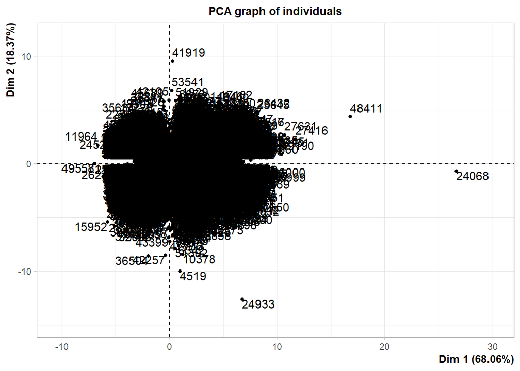

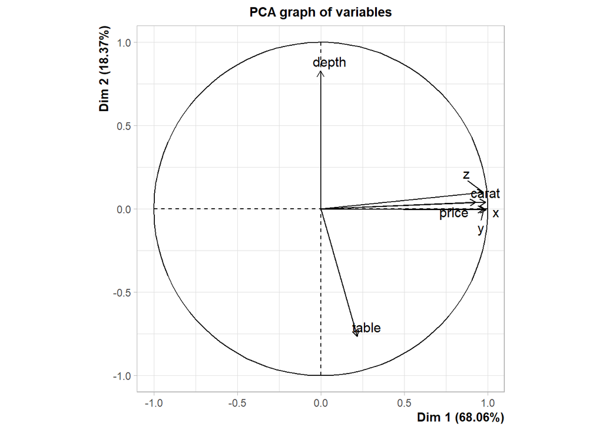

```r
PCA.factminor=PCA(R.diamond[,c(-1,-3,-4,-5)])
```

```r
print("Print Eigen values")
```

```
## [1] "Print Eigen values"
```

```r
PCA.factminor$eig #the eig values give the cumulative % of the data covered
```

```
##        eigenvalue percentage of variance cumulative percentage of variance
## comp 1 4.76391480             68.0559258                          68.05593
## comp 2 1.28586808             18.3695440                          86.42547
## comp 3 0.69081126              9.8687323                          96.29420
## comp 4 0.17375333              2.4821905                          98.77639
## comp 5 0.04030722              0.5758174                          99.35221
## comp 6 0.03294659              0.4706656                          99.82288
## comp 7 0.01239871              0.1771245                         100.00000
```

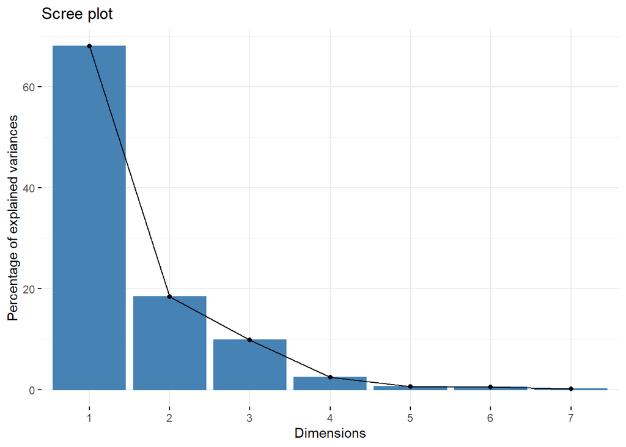

```r
#Extract the eigenvalues/variances of the principal dimensions. fviz_eig() (or fviz_screeplot()): Plot the eigenvalues/variances against the number of dimensions.

library(factoextra)
fviz_screeplot(PCA.factminor) # function for Screeplot
```

```r
#rajkr82-covariance identified for the train dataset and excluding the columns 1 & from 3 till 5

print("Print covariance among the variables")
```

```
## [1] "Print covariance among the variables"
```

```r
R.cor.train = cor(train.dia[ ,c(-1,-3,-4,-5)])
R.cor.train
```

```
##            carat       depth      table       price           x           y
## carat 1.00000000  0.02924937  0.1858552  0.92057626  0.97529267  0.94385021
## depth 0.02924937  1.00000000 -0.2898838 -0.01002753 -0.02501984 -0.02978768
## table 0.18585520 -0.28988379  1.0000000  0.13061089  0.20015865  0.18661779
## price 0.92057626 -0.01002753  0.1306109  1.00000000  0.88388935  0.85754492
## x     0.97529267 -0.02501984  0.2001586  0.88388935  1.00000000  0.96610639
## y     0.94385021 -0.02978768  0.1866178  0.85754492  0.96610639  1.00000000
## z     0.94756889  0.09443426  0.1549389  0.85541065  0.96461927  0.93945414
##                z
## carat 0.94756889
## depth 0.09443426
## table 0.15493893
## price 0.85541065
## x     0.96461927
## y     0.93945414
## z     1.00000000
```

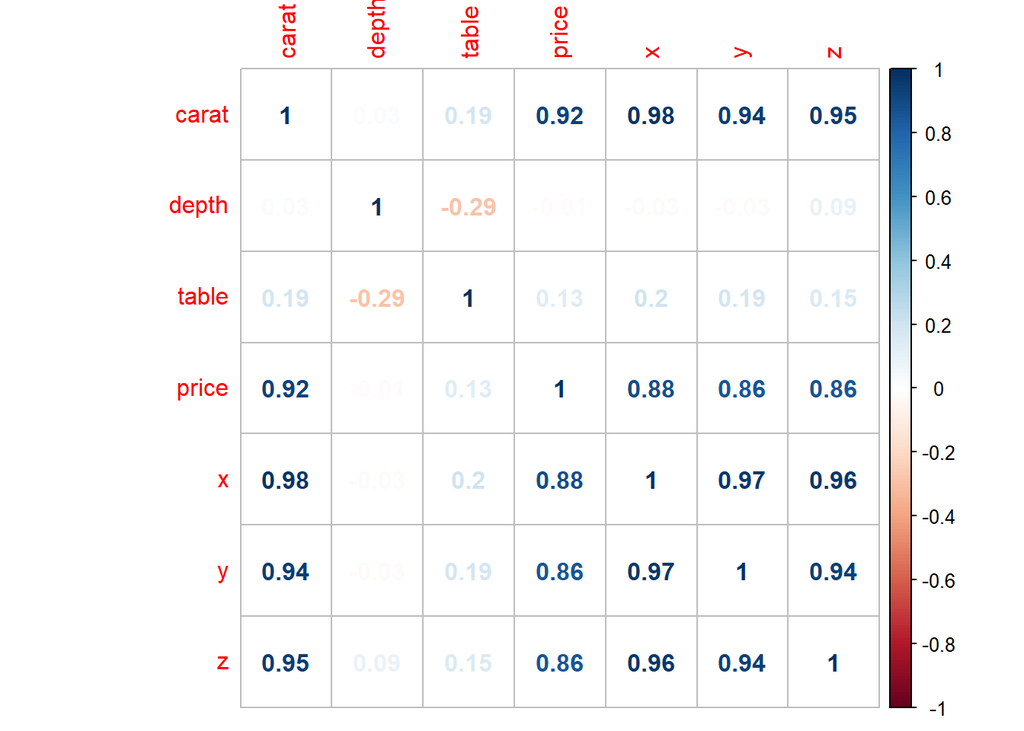

```r
library(corrplot)#rajkr82- Correlation between Variables# Price Positively correlated with Carat length Width & #Depth
corrplot(R.cor.train, method = "number")
```

#rajkr82-Shows the attributes of the PCA.diamond

#rajkr82# center and scale refers to respective mean and standard deviation of the variables that are used for normalization prior to implementing PCA

```r
#printing the attributes

print("printing the attributes ")
```

```
## [1] "printing the attributes "
```

```r
attributes(PCA.diamond)
```

```
## $names
## [1] "sdev"     "rotation" "center"   "scale"    "x"
##
## $class
## [1] "prcomp"
```

```r
print("attributes of $sdev")
```

```
## [1] "attributes of $sdev"
```

```r
PCA.diamond$sdev
```

```
## [1] 2.1779432 1.1310113 0.8340341 0.4210365 0.2301464 0.1937737 0.1182236
```

```r
print("attributes of $centre")
```

```
## [1] "attributes of $centre"
```

```r
PCA.diamond$center
```

```
##        carat        depth        table        price            x            y
##    0.7979841   61.7537460   57.4606286 3933.1031125    5.7308369    5.7347516
##            z
##    3.5388672
```

```r
print("attributes of $scale")
```

```
## [1] "attributes of $scale"
```

```r
PCA.diamond$scale
```

```
##        carat        depth        table        price            x            y
##    0.4743593    1.4341855    2.2403575 3989.4379003    1.1220461    1.1529461
##            z
##    0.7102205
```

#rajkr82:- SPLOM, Histograms And Correlations For A Data Matrix Adapted from the help page for pairs, pairs.panels shows a scatter plot of matrices (SPLOM), with bivariate scatter plots below the diagonal, histograms on the diagonal, and the Pearson correlation above the diagonal. Useful for descriptive statistics. Correlation ellipses are also shown. Points may be given different colors depending upon some grouping variable.

```r
library(psych)
```

```r
#orthagonality of PCA's
#here we are finding the corelation to see how many points are falling into the circle.

#pairs.panels(PCA.diamond$x,bg=c("red","yellow","blue")[train$cut],
#pch=21,main="Diamond data by cut")# Center is the mid point in the X-Y axis to decide where the ellipses falls in the four quardrants.
#plotting Biplot for PCA
#biplot(PCA.diamond)
#plotting 2D & 3D plot for PCA
#pca2d(PCA.diamond)
library(pca3d)
pca3d(PCA.diamond)
```

```
## [1] 0.5271031 0.2510610 0.2648861
## Creating new device
```

```r
#pca2d(PCA.diamond, biplot=TRUE, biplot.vars=3)
#pca3d(PCA.diamond, fancy=TRUE)
```

```r
#now predection is done using Train dataset
PredictTrain <- predict(PCA.diamond, train.dia)
print("Printing summary of predictraindiamond")
```

```
## [1] "Printing summary of predictraindiamond"
```

```r
summary(PredictTrain)# Here we see the Box plot values of PC1 till PC7
```

```
##       PC1               PC2               PC3                 PC4
##  Min.   :-6.9148   Min.   :-9.5421   Min.   :-13.24431   Min.   :-7.77588
##  1st Qu.:-1.9233   1st Qu.:-0.7113   1st Qu.: -0.49450   1st Qu.:-0.23938
##  Median :-0.2645   Median :-0.1634   Median :  0.09952   Median : 0.03682
##  Mean   : 0.0000   Mean   : 0.0000   Mean   :  0.00000   Mean   : 0.00000
##  3rd Qu.: 1.3926   3rd Qu.: 0.5648   3rd Qu.:  0.58349   3rd Qu.: 0.28598
##  Max.   :26.3552   Max.   :12.5531   Max.   :  9.96395   Max.   :16.67325
##       PC5                  PC6                 PC7
##  Min.   :-30.906673   Min.   :-4.662092   Min.   :-1.53720
##  1st Qu.: -0.018760   1st Qu.:-0.040917   1st Qu.:-0.05545
##  Median : -0.001004   Median :-0.003229   Median :-0.01458
##  Mean   :  0.000000   Mean   : 0.000000   Mean   : 0.00000
##  3rd Qu.:  0.019800   3rd Qu.: 0.043173   3rd Qu.: 0.04981
##  Max.   : 24.846448   Max.   :20.373768   Max.   : 9.23698
```

```r
PredictTrain = data.frame(PredictTrain, train.dia[3])# Train dataset cut is the 3rd column.
```

```r
#predicting using the test data set
PredictTestdiamond = predict(PCA.diamond, test.dia)
print("Printing summary of PredictTest")
```

```
## [1] "Printing summary of PredictTest"
```

```r
summary(PredictTestdiamond)
```

```
##       PC1                 PC2                 PC3
##  Min.   :-6.914847   Min.   :-5.779737   Min.   :-13.24431
##  1st Qu.:-1.912945   1st Qu.:-0.715092   1st Qu.: -0.47994
##  Median :-0.261773   Median :-0.174638   Median :  0.11453
##  Mean   :-0.000993   Mean   : 0.004419   Mean   :  0.01156
##  3rd Qu.: 1.390566   3rd Qu.: 0.565728   3rd Qu.:  0.57490
##  Max.   :10.641312   Max.   : 8.564821   Max.   :  9.77767
##       PC4                 PC5                 PC6
##  Min.   :-6.405539   Min.   :-4.430110   Min.   :-4.037254
##  1st Qu.:-0.234187   1st Qu.:-0.018634   1st Qu.:-0.040874
##  Median : 0.039292   Median :-0.000433   Median :-0.003952
##  Mean   : 0.000871   Mean   : 0.001274   Mean   :-0.000646
##  3rd Qu.: 0.286470   3rd Qu.: 0.020602   3rd Qu.: 0.043227
##  Max.   : 1.392421   Max.   : 1.553741   Max.   : 1.429869
##       PC7
##  Min.   :-1.4596284
##  1st Qu.:-0.0557845
##  Median :-0.0145724
##  Mean   :-0.0006242
##  3rd Qu.: 0.0496934
##  Max.   : 2.7505056
```

```r
PredictTestdiamond = data.frame(PredictTestdiamond, test.dia[3])# Test dataset cut is the 3rd column.
```

```r
library(nnet)#I want to use the multinomial logistic regression in nnet package. The Cut outcome has 5 factors
PredictTrain$cut= relevel(PredictTrain$cut, ref = "Fair")#since Fair class didn't appear in the output, it means that it was treated as base being the first one in alphabetical order as expected when dealing with factor variables in R.
mytrainmodel = multinom(cut~ PC1 + PC2, data=PredictTrain)# Considered till PC2.
print("Printing summary of my model")
```

```
## [1] "Printing summary of my model"
```

```r
summary(mytrainmodel)
```

```
## Call:
## multinom(formula = cut ~ PC1 + PC2, data = PredictTrain)
##
## Coefficients:
##           (Intercept)         PC1       PC2
## Good         1.430311 -0.09969040 0.8217929
## Ideal        2.789376 -0.28169516 0.3003632
## Premium      2.314098 -0.05003383 1.2644665
## Very Good    2.332342 -0.13834758 0.8799097
##
## Std. Errors:
##           (Intercept)        PC1        PC2
## Good       0.04078577 0.01433692 0.03503346
## Ideal      0.03815509 0.01287026 0.03139537
## Premium    0.03880603 0.01315848 0.03284738
## Very Good  0.03864775 0.01320221 0.03274933
##
## Residual Deviance: 100267.5
## AIC: 100291.5
```

```r
##Confusion MAtrix , Accuracy, Sensitivity & Specificity for Train dataset#######
pot1 = predict(mytrainmodel, PredictTrain)
library(caret)
confusionMatrix(pot1, PredictTrain$cut)
```

```
## Confusion Matrix and Statistics
##
##            Reference
## Prediction   Fair  Good Ideal Premium Very Good
##   Fair          8     0     0       0         1
##   Good          0     0     0       0         0
##   Ideal       926  2337 14387    4417      5782
##   Premium     277  1223  1282    5614      2975
##   Very Good     0     0     0       0         0
##
## Overall Statistics
##
##                Accuracy : 0.5101
##                  95% CI : (0.5051, 0.515)
##     No Information Rate : 0.3994
##     P-Value [Acc > NIR] : < 2.2e-16
##
##                   Kappa : 0.2372
##
##  Mcnemar's Test P-Value : NA
##
## Statistics by Class:
##
##                      Class: Fair Class: Good Class: Ideal Class: Premium
## Sensitivity            0.0066061     0.00000       0.9182         0.5597
## Specificity            0.9999737     1.00000       0.4286         0.8028
## Pos Pred Value         0.8888889         NaN       0.5166         0.4937
## Neg Pred Value         0.9693269     0.90925       0.8873         0.8414
## Prevalence             0.0308700     0.09075       0.3994         0.2557
## Detection Rate         0.0002039     0.00000       0.3667         0.1431
## Detection Prevalence   0.0002294     0.00000       0.7099         0.2899
## Balanced Accuracy      0.5032899     0.50000       0.6734         0.6812
##                      Class: Very Good
## Sensitivity                    0.0000
## Specificity                    1.0000
## Pos Pred Value                    NaN
## Neg Pred Value                 0.7767
## Prevalence                     0.2233
## Detection Rate                 0.0000
## Detection Prevalence           0.0000
## Balanced Accuracy              0.5000
```

```r
#Confusion matrix & misclassification error for Training set###

pot1 = predict(mytrainmodel, PredictTrain)
tab12 = table(pot1, PredictTrain$cut)
tab12
```

```
##
## pot1         Fair  Good Ideal Premium Very Good
##   Fair          8     0     0       0         1
##   Good          0     0     0       0         0
##   Ideal       926  2337 14387    4417      5782
##   Premium     277  1223  1282    5614      2975
##   Very Good     0     0     0       0         0
```

```r
print("Printing error % for  predictTrain")
```

```
## [1] "Printing error % for  predictTrain"
```

```r
1 - sum(diag(tab12))/sum(tab12)
```

```
## [1] 0.4899437
```

Each row of the matrix corresponds to a predicted class. Each column of the matrix corresponds to an actual class.

```r
##Confusion MAtrix , Accuracy, Sensitivity & Specificity for Test dataset####

pot2 = predict(mytrainmodel, PredictTestdiamond)
confusionMatrix(pot2, PredictTestdiamond$cut)
```

```
## Confusion Matrix and Statistics
##
##            Reference
## Prediction  Fair Good Ideal Premium Very Good
##   Fair         5    0     0       0         0
##   Good         0    0     0       0         0
##   Ideal      309  904  5424    1621      2191
##   Premium     85  442   458    2139      1133
##   Very Good    0    0     0       0         0
##
## Overall Statistics
##
##                Accuracy : 0.5144
##                  95% CI : (0.5063, 0.5226)
##     No Information Rate : 0.3998
##     P-Value [Acc > NIR] : < 2.2e-16
##
##                   Kappa : 0.2437
##
##  Mcnemar's Test P-Value : NA
##
## Statistics by Class:
##
##                      Class: Fair Class: Good Class: Ideal Class: Premium
## Sensitivity            0.0125313      0.0000       0.9221         0.5689
## Specificity            1.0000000      1.0000       0.4309         0.8066
## Pos Pred Value         1.0000000         NaN       0.5191         0.5025
## Neg Pred Value         0.9732082      0.9085       0.8925         0.8449
## Prevalence             0.0271226      0.0915       0.3998         0.2556
## Detection Rate         0.0003399      0.0000       0.3687         0.1454
## Detection Prevalence   0.0003399      0.0000       0.7103         0.2894
## Balanced Accuracy      0.5062657      0.5000       0.6765         0.6877
##                      Class: Very Good
## Sensitivity                     0.000
## Specificity                     1.000
## Pos Pred Value                    NaN
## Neg Pred Value                  0.774
## Prevalence                      0.226
## Detection Rate                  0.000
## Detection Prevalence            0.000
## Balanced Accuracy               0.500
```

```r
#####
#confusion matrix & misclassification error - Testing

pot2 = predict(mytrainmodel, PredictTestdiamond)
tab21 = table(pot2, PredictTestdiamond$cut)
tab21
```

```
##
## pot2        Fair Good Ideal Premium Very Good
##   Fair         5    0     0       0         0
##   Good         0    0     0       0         0
##   Ideal      309  904  5424    1621      2191
##   Premium     85  442   458    2139      1133
##   Very Good    0    0     0       0         0
```

```r
print("Printing error % for  predictTest")
```

```
## [1] "Printing error % for  predictTest"
```

```r
1 - sum(diag(tab21))/sum(tab21)
```

```
## [1] 0.485555
```

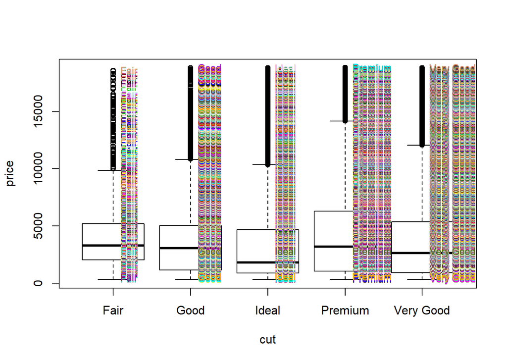

```r
plot(price ~ cut,R.diamond)
with(R.diamond,text(price ~ cut, labels=cut, pos = 4, cex =0.8, col = price))# Pos is position, CEX is font Size
```

scale , with default settings, will calculate the mean and standard deviation of the entire vector, then “scale” each element by those values by subtracting the mean and dividing by the sd.

apply():- They act on an input list, matrix or array and apply a named function with one or several optional arguments. The called function could be: 1.An aggregating function, like for example the mean, or the sum (that return a number or scalar); 2.Other transforming or subsetting functions; and 3.Other vectorized functions, which yield more complex structures like lists, vectors, matrices, and arrays.

```r
# Normalisation
z3 <- R.diamond[ 1:10,c(-1,-3,-4,-5)]# Remove the unwanted columns.Due to memomory Size error msg. i have taken only 10 rows from R.diamond.
mn = apply(z3,2,mean)## mean for the variable z3 and 2 indicates column as per apply function
print("Mean")
```

```
## [1] "Mean"
```

```r
mn
```

```
##   carat   depth   table   price       x       y       z
##   0.246  61.540  58.800 333.200   4.026   4.035   2.479
```

```r
stddev <- apply(z3,2,sd)# Stdev for the variable z3 and 2 indicates column as per apply function
print("Stddev")
```

```
## [1] "Stddev"
```

```r
stddev
```

```
##      carat      depth      table      price          x          y          z
## 0.03169297 2.30805353 3.15524255 4.87168691 0.14675755 0.16965652 0.13601062
```

```r
print("Scale of Z3")
```

```
## [1] "Scale of Z3"
```

```r
z3 <-  scale(z3,mn,stddev)
z3
```

```
##         carat       depth      table      price          x           y
## 1  -0.5048438 -0.01733062 -1.2043448 -1.4779275 -0.5178609 -0.32418442
## 2  -1.1358985 -0.75388199  0.6972523 -1.4779275 -0.9266985 -1.14938114
## 3  -0.5048438 -2.01035198  1.9649836 -1.2726598  0.1635350  0.20629918
## 4   1.3883204  0.37260834 -0.2535463  0.1642142  1.1856290  1.14938114
## 5   2.0193752  0.76254730 -0.2535463  0.3694819  2.1395833  1.85669262
## 6  -0.1893164  0.54591455 -0.5704791  0.5747496 -0.5860005 -0.44206967
## 7  -0.1893164  0.32928179 -0.5704791  0.5747496 -0.5178609 -0.32418442
## 8   0.4417383  0.15597558 -1.2043448  0.7800173  0.2998142  0.44206967
## 9  -0.8203712  1.54242523  0.6972523  0.7800173 -1.0629777 -1.50303688
## 10 -0.5048438 -0.92718820  0.6972523  0.9852850 -0.1771629  0.08841393
##               z
## 1  -0.360265984
## 2  -1.242550026
## 3  -1.242550026
## 4   1.110207419
## 5   1.992491461
## 6   0.007352367
## 7  -0.066171303
## 8   0.374970718
## 9   0.080876037
## 10 -0.654360664
## attr(,"scaled:center")
##   carat   depth   table   price       x       y       z
##   0.246  61.540  58.800 333.200   4.026   4.035   2.479
## attr(,"scaled:scale")
##      carat      depth      table      price          x          y          z
## 0.03169297 2.30805353 3.15524255 4.87168691 0.14675755 0.16965652 0.13601062
```

```r
#Calculate the Euclidian distance
distance <-dist(z3)# Since only 10 rows are taken into consideration
print(distance)
```

```
##            1         2         3         4         5         6         7
## 2  2.4866307
## 3  3.9475372 2.5792834
## 4  3.8173729 5.1500497 4.8701745
## 5  5.3526192 6.7436123 6.2268142 1.6676813
## 6  2.2772252 3.2534190 4.3611914 3.1105683 4.6606568
## 7  2.2184360 3.1814858 4.1886175 3.0359416 4.6113930 0.2662244
## 8  2.7965476 4.3225672 4.7473837 2.0128858 3.4542302 1.6418637 1.5239849
## 9  3.6232904 3.5165324 4.9719241 4.5476475 5.9112925 2.0974045 2.2864149
## 10 3.2991108 2.9892454 2.8904394 3.5983706 5.1000066 2.2207423 2.0214440
##            8         9
## 2
## 3
## 4
## 5
## 6
## 7
## 8
## 9  3.5858566
## 10 2.6719975 3.1778356
```

A dendrogram is a diagram that shows the hierarchical relationship between objects. It is most commonly created as an output from hierarchical clustering. The main use of a dendrogram is to work out the best way to allocate objects to clusters.

Hierarchical Cluster Analysis. … The hclust function in R uses the complete linkage method for hierarchical clustering by default. This particular clustering method defines the cluster distance between two clusters to be the maximum distance between their individual components.

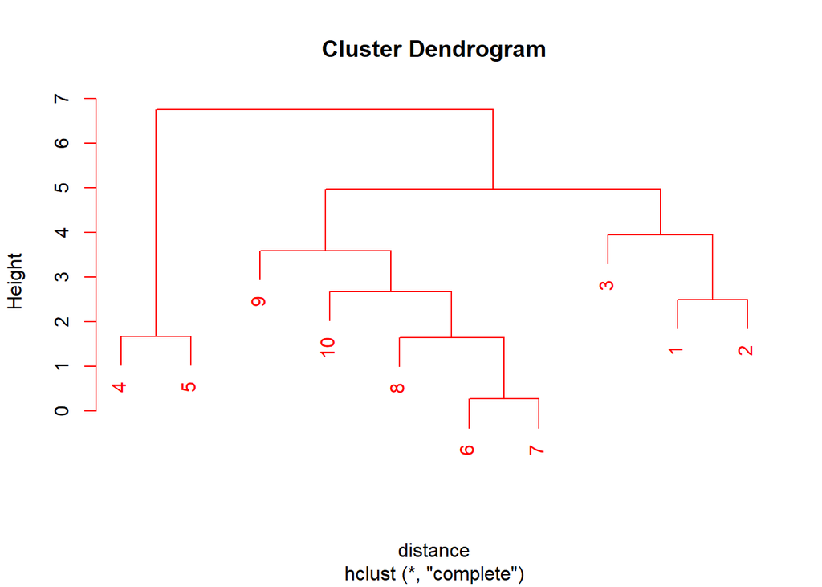

```r
#cluster Dendrogram with complex Linkage

hc1 <-hclust(distance)
plot(hc1,labels = R.diamond$Cut, col = R.diamond$price)
```

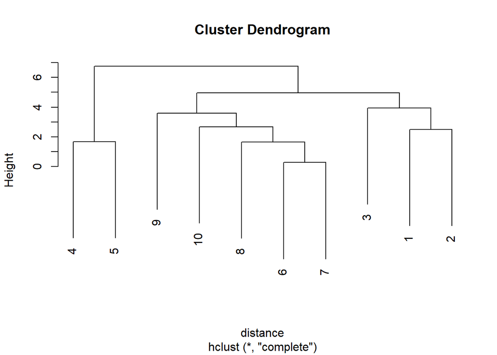

```r
plot(hc1,hang = 1,labels = R.diamond$Cut)
```

In Average linkage clustering, the distance between two clusters is defined as the average of distances between all pairs of objects, where each pair is made up of one object from each group.

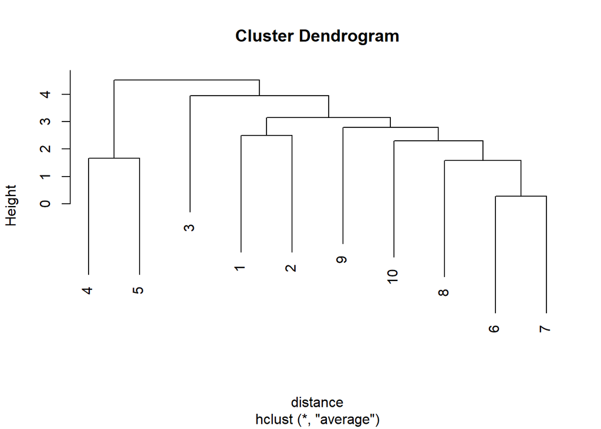

```r
#cluster Dendrogram with Average Linkage
hc.a1 = hclust(distance,method = "average")
plot(hc.a1,labels = R.diamond$Cut,hang = 1)
```

Table function in R -table(), performs categorical tabulation of data with the variable and its frequency. Table() function is also helpful in creating Frequency tables with condition and cross tabulations.

```r
#Cluster membership
member.c1 <- cutree(hc1,3)# compressing to 3 clusters.Here hc1 is the complete linkage
member.a1 <- cutree(hc.a1,3)# here hc.a1 is average linkage
table(member.c1,member.a1)# Here the table show it belongs to which cluster.
```

```
##          member.a1
## member.c1 1 2 3
##         1 2 1 0
##         2 0 0 2
##         3 5 0 0
```

```r
#Cluster means
aggregate(z3,list(member.c1),mean)# New Z3 variable u are find mean in member.c
```

```
##   Group.1      carat      depth      table      price          x          y
## 1       1 -0.7151954 -0.9271882  0.4859637 -1.4095049 -0.4270081 -0.4224221
## 2       2  1.7038478  0.5675778 -0.2535463  0.2668480  1.6626061  1.5030369
## 3       3 -0.2524219  0.3292818 -0.1901597  0.7389637 -0.4088376 -0.3477615
##             z
## 1 -0.94845535
## 2  1.55134944
## 3 -0.05146657
```

```r
aggregate(R.diamond[ 1:10,c(-1,-3,-4,-5)],list(member.c1),mean)# Here u aggregating the entire R.diamond dataset with member.c1
```

```
##   Group.1     carat depth    table    price        x        y     z
## 1       1 0.2233333 59.40 60.33333 326.3333 3.963333 3.963333 2.350
## 2       2 0.3000000 62.85 58.00000 334.5000 4.270000 4.290000 2.690
## 3       3 0.2380000 62.30 58.20000 336.8000 3.966000 3.976000 2.472
```

The silhouette plot displays a measure of how close each point in one cluster is to points in the neighboring clusters.

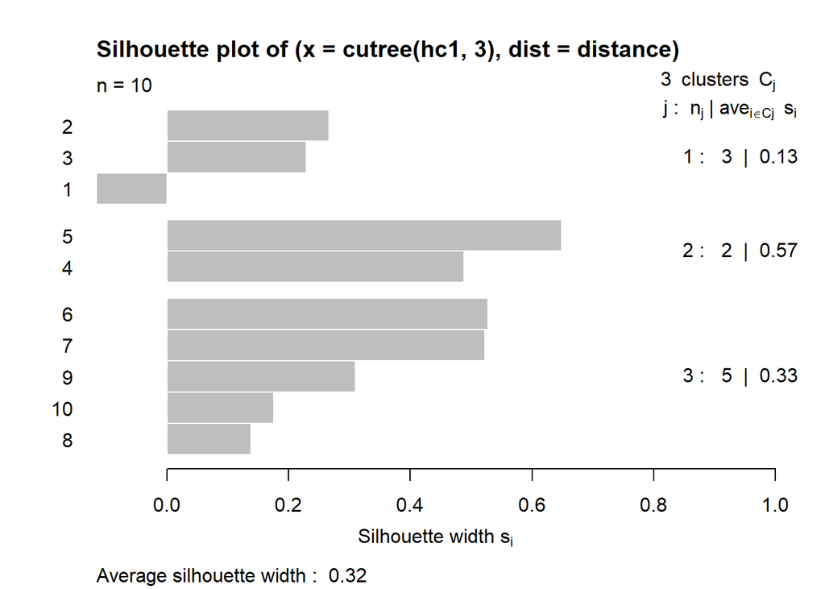

```r
#Silhouette Plot
library(cluster)
plot(silhouette(cutree(hc1,3),distance))
```

# Non Hiearcheal Clustering

```r
z2 <- R.diamond[ ,c(-1,-3,-4,-5)]
kclus<-kmeans(z2,8)
kclus
```

```
## K-means clustering with 8 clusters of sizes 3484, 1583, 5577, 1924, 2570, 10897, 20010, 7895
##
## Cluster means:
##       carat    depth    table      price        x        y        z
## 1 1.2783783 61.76949 57.70301  7920.2500 6.928232 6.924842 4.277408
## 2 1.9825458 61.60493 58.02748 16861.9267 8.019848 8.011642 4.925111
## 3 1.1244970 61.78601 57.80267  5759.2731 6.646615 6.641377 4.103167
## 4 1.7557588 61.70249 57.90572 13416.2084 7.700951 7.716440 4.747391
## 5 1.4701479 61.62875 57.71899 10473.8113 7.265763 7.262346 4.475553
## 6 0.6550509 61.72263 57.42516  2231.5481 5.551965 5.556707 3.429692
## 7 0.3677041 61.72596 57.01120   841.4334 4.581292 4.589843 2.830072
## 8 0.9531476 61.89073 57.97032  4033.4930 6.279419 6.278396 3.883187
##
## Clustering vector:
##     [1] 7 7 7 7 7 7 7 7 7 7 7 7 7 7 7 7 7 7 7 7 7 7 7 7 7 7 7 7 7 7 7 7 7 7 7 7
```

[output cut: 1508 more lines]

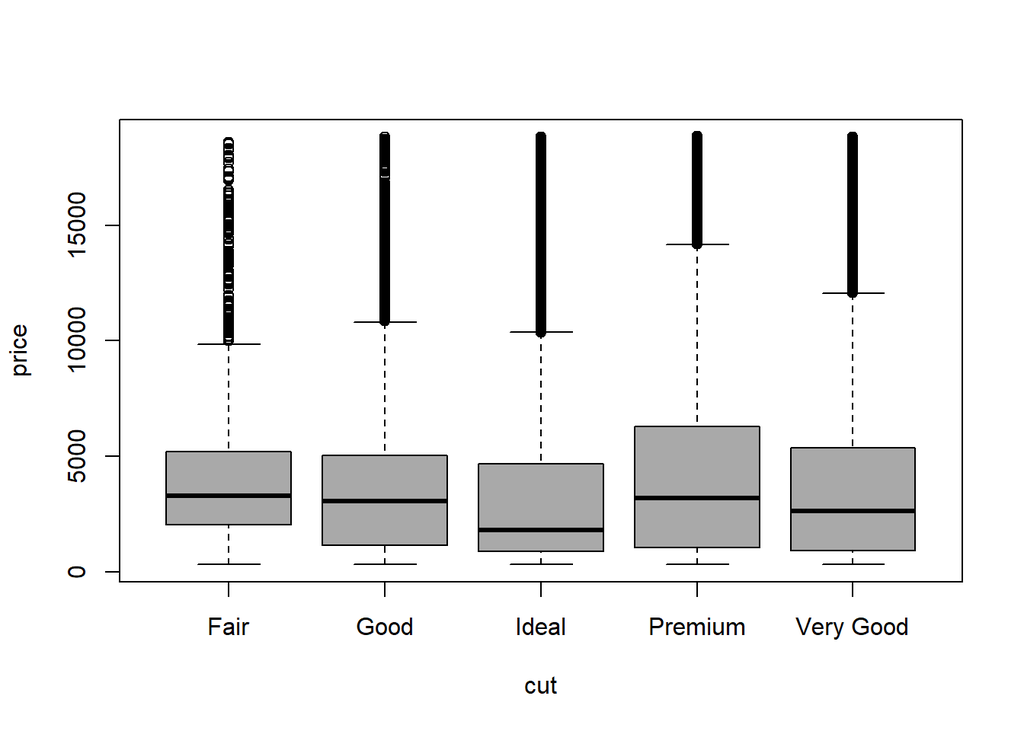

```r
plot(price~ cut,R.diamond,col= kclus$cluster)
```